# Exceedance probability comparison for the simplified Naomi model

Adam Howes

Abstract

**Background** We have run the simplified Naomi model using a range of inference methods: `TMB`, `aghq`, `adam` and `tmbstan`.

**Task** In this report, we compare the accuracy of the posterior distributions obtained from these inference methods using exceedance probabilities.

# 1 Background

```r
tmb <- readRDS("depends/tmb.rds")
aghq <- readRDS("depends/aghq.rds")
tmbstan <- readRDS("depends/tmbstan.rds")
```

# 2 Second 90

The 90-90-90 treatment targets are that

- 90% of PLHIV know their status
- 90% of PLHIV who kno wtheir status are on antiretroviral therapy (ART)
- 90% of PLHIV on ART have suppressed viral load

To meet the second 90, we require that $90\% \times 90\% = 81\%$ of PLHIV are on ART.

```r
mf_out <- tmb$naomi_data$mf_out

mf_out_fine <- mf_out %>%
  tibble::rownames_to_column("id") %>%
  mutate(id = as.numeric(id)) %>%
  filter(
    area_id %in% paste0("MWI_4_", 1:32, "_demo"),
    sex %in% c("male", "female"),
    age_group %in%
      c(
        "Y000_004", "Y005_009", "Y010_014", "Y015_019", "Y020_024", "Y025_029",
        "Y025_034", "Y030_034", "Y035_039", "Y040_044", "Y045_049", "Y050_054",
        "Y055_059", "Y060_064", "Y065_069", "Y070_074", "Y075_079", "Y080_999"
      )
  )

tmbstan_second90 <- apply(tmbstan$mcmc$sample$alpha_t1_out[mf_out_fine$id, ], 1, function(x) sum(x > 0.81) / length(x))
tmb_second90 <- apply(tmb$fit$sample$alpha_t1_out[mf_out_fine$id, ], 1, function(x) sum(x > 0.81) / length(x))
aghq_second90 <- apply(aghq$quad$sample$alpha_t1_out[mf_out_fine$id, ], 1, function(x) sum(x > 0.81) / length(x))
```

Plot the results from the different inference methods:

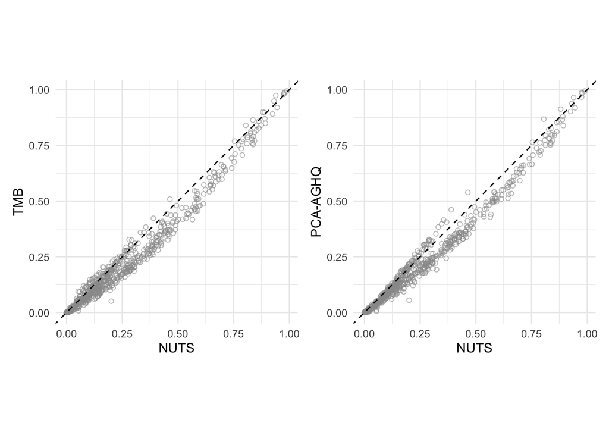

```r
n <- length(tmbstan_second90)
stopifnot(length(tmb_second90) == n)
stopifnot(length(aghq_second90) == n)

df_second90 <- data.frame(
  prob = c(tmbstan_second90, tmb_second90, aghq_second90),
  method = c(rep("tmbstan", times = n), rep("TMB", times = n), rep("aghq", times = n)),
  index = c(1:n, 1:n, 1:n)
)

df_wide_second90 <- pivot_wider(df_second90, names_from = method, values_from = prob)

plot1 <- ggplot(df_wide_second90, aes(x = tmbstan, y = TMB)) +
  geom_point(shape = 1, alpha = 0.6, col = "#999999") +
  coord_fixed(ratio = 1) +
  geom_abline(slope = 1, intercept = 0, linetype = "dashed") +
  labs(x = "NUTS", y = "TMB") +
  theme_minimal()

plot2 <- ggplot(df_wide_second90, aes(x = tmbstan, y = aghq)) +
  geom_point(shape = 1, alpha = 0.6, col = "#999999") +
  coord_fixed(ratio = 1) +
  geom_abline(slope = 1, intercept = 0, linetype = "dashed") +
  labs(x = "NUTS", y = "PCA-AGHQ") +
  theme_minimal()

plot1 + plot2
```

What is the correlation?

```r
cor(tmbstan_second90, tmb_second90)
```

```
## [1] 0.9896333
```

```r
cor(tmbstan_second90, aghq_second90)
```

```
## [1] 0.9918411
```

And what about the mean square error and root mean square error?

```r
(mse_tmb_second90 <- mean((tmbstan_second90 - tmb_second90)^2))
```

```
## [1] 0.001634993
```

```r
(mse_aghq_second90 <- mean((tmbstan_second90 - aghq_second90)^2))
```

```
## [1] 0.001355959
```

```r
(rmse_tmb_second90 <- sqrt(mse_tmb_second90))
```

```
## [1] 0.04043505
```

```r
(rmse_aghq_second90 <- sqrt(mse_aghq_second90))
```

```
## [1] 0.03682334
```

```r
mse_change <- round(100 * (mse_aghq_second90 - mse_tmb_second90) / mse_tmb_second90)
rmse_change <- round(100 * (rmse_aghq_second90 - rmse_tmb_second90) / rmse_tmb_second90)
```

There is a change of -17% in the MSE moving from `TMB` to `aghq`, and a change of -9% in the RMSE.

Which strata have exceedance probabilities which are particularly poorly estimated? First for `TMB`:

```r
tmb_fails_second90 <- df_wide_second90 %>%
  mutate(diff = tmbstan - TMB) %>%
  filter(diff > 0.1) %>%
  pull(index)
```

And for `aghq`:

```r
aghq_fails_second90 <- df_wide_second90 %>%
  mutate(diff = tmbstan - aghq) %>%
  filter(diff > 0.1) %>%
  pull(index)
```

There are 39 uniquely badly estimated by `TMB`, 16 uniquely badly estimated by `aghq`, and 8 badly estimated by both. Which strata do these correspond to?

```r
unique(mf_out_fine[tmb_fails_second90, ]$area_id)
```

```
##  [1] "MWI_4_1_demo"  "MWI_4_10_demo" "MWI_4_11_demo" "MWI_4_12_demo" "MWI_4_13_demo" "MWI_4_14_demo"
##  [7] "MWI_4_17_demo" "MWI_4_18_demo" "MWI_4_19_demo" "MWI_4_21_demo" "MWI_4_23_demo" "MWI_4_25_demo"
## [13] "MWI_4_29_demo" "MWI_4_3_demo"  "MWI_4_30_demo" "MWI_4_31_demo" "MWI_4_32_demo" "MWI_4_4_demo"
## [19] "MWI_4_7_demo"  "MWI_4_8_demo"
```

```r
unique(mf_out_fine[tmb_fails_second90, ]$sex)
```

```
## [1] "female"
```

```r
unique(mf_out_fine[tmb_fails_second90, ]$age_group)
```

```
## [1] "Y045_049" "Y080_999" "Y060_064" "Y065_069" "Y040_044" "Y070_074" "Y075_079" "Y025_034" "Y055_059"
```

```r
unique(mf_out_fine[aghq_fails_second90, ]$area_id)
```

```
##  [1] "MWI_4_11_demo" "MWI_4_13_demo" "MWI_4_17_demo" "MWI_4_19_demo" "MWI_4_21_demo" "MWI_4_23_demo"
##  [7] "MWI_4_25_demo" "MWI_4_31_demo" "MWI_4_4_demo"  "MWI_4_7_demo"
```

```r
unique(mf_out_fine[aghq_fails_second90, ]$sex)
```

```
## [1] "female"
```

```r
unique(mf_out_fine[aghq_fails_second90, ]$age_group)
```

```
## [1] "Y045_049" "Y040_044" "Y050_054" "Y055_059" "Y060_064" "Y065_069" "Y030_034" "Y025_034" "Y080_999"
```

Add colour by sex to the above plots:

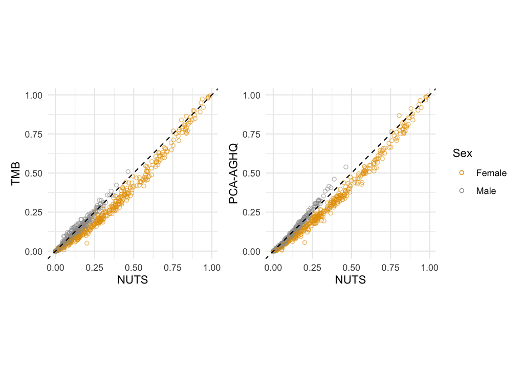

```r
df_wide_second90 <- df_wide_second90 %>%
  left_join(
    mf_out_fine %>%
      tibble::rowid_to_column("index"),
    by = "index"
  )

plot1 <- ggplot(df_wide_second90, aes(x = tmbstan, y = TMB, col = sex)) +
  geom_point(shape = 1, alpha = 0.6) +
  coord_fixed(ratio = 1) +
  scale_color_manual(values = c("#E69F00", "#999999")) +
  geom_abline(slope = 1, intercept = 0, linetype = "dashed") +
  labs(col = "Sex") +
  guides(col = "none") +
  labs(x = "NUTS", y = "TMB") +
  theme_minimal()

plot2 <- ggplot(df_wide_second90, aes(x = tmbstan, y = aghq, col = sex)) +
  geom_point(shape = 1, alpha = 0.6) +
  coord_fixed(ratio = 1) +
  scale_colour_manual(values = c("#E69F00", "#999999"), labels = c("Female", "Male")) +
  geom_abline(slope = 1, intercept = 0, linetype = "dashed") +
  guides(colour = guide_legend(override.aes = list(alpha = 1))) +
  labs(x = "NUTS", y = "PCA-AGHQ", col = "Sex") +
  theme_minimal()

ggsave("second90.png", plot1 + plot2, h = 4, w = 6.25)

plot1 + plot2
```

Check the RMSE stratified by sex:

```r
df_wide_second90 %>%
  group_by(sex) %>%
  summarise(
    "RMSE TMB (percent)" = 100 * sqrt(mean((tmbstan - TMB)^2)),
    "RMSE aghq (percent)" = 100 * sqrt(mean((tmbstan - aghq)^2))
  )
```

| sex | RMSE TMB (percent) | RMSE aghq (percent) |
| --- | --- | --- |
| female | 5.548339 | 5.064998 |
| male | 1.384124 | 1.210361 |

# 3 High incidence strata

Above 1% incidence is considered high, and could be met with intensified interventions.

- Very high (>3%)
- High (1-3%)
- Moderate (0.3-1%)
- Low (<0.3%)

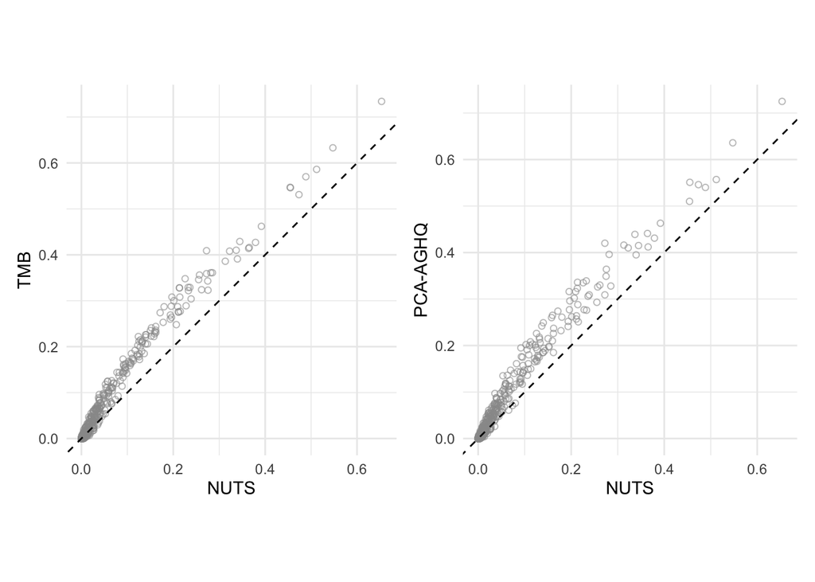

```r
tmbstan_1inc <- apply(tmbstan$mcmc$sample$lambda_t1_out[mf_out_fine$id, ], 1, function(x) sum(x > 0.01) / length(x))
tmb_1inc <- apply(tmb$fit$sample$lambda_t1_out[mf_out_fine$id, ], 1, function(x) sum(x > 0.01) / length(x))
aghq_1inc <- apply(aghq$quad$sample$lambda_t1_out[mf_out_fine$id, ], 1, function(x) sum(x > 0.01) / length(x))

n <- length(tmbstan_1inc)
stopifnot(length(tmb_1inc) == n)
stopifnot(length(aghq_1inc) == n)

df_1inc <- data.frame(
  prob = c(tmbstan_1inc, tmb_1inc, aghq_1inc),
  method = c(rep("tmbstan", times = n), rep("TMB", times = n), rep("aghq", times = n)),
  index = c(1:n, 1:n, 1:n)
)

df_wide_1inc <- pivot_wider(df_1inc, names_from = method, values_from = prob)

df_wide_1inc <- df_wide_1inc %>%
  left_join(
    mf_out_fine %>%
      tibble::rowid_to_column("index"),
    by = "index"
  )

plot1 <- ggplot(df_wide_1inc, aes(x = tmbstan, y = TMB)) +
  geom_point(shape = 1, alpha = 0.6, col = "#999999") +
  coord_fixed(ratio = 1) +
  geom_abline(slope = 1, intercept = 0, linetype = "dashed") +
  labs(x = "NUTS", y = "TMB") +
  theme_minimal()

plot2 <- ggplot(df_wide_1inc, aes(x = tmbstan, y = aghq)) +
  geom_point(shape = 1, alpha = 0.6, col = "#999999") +
  coord_fixed(ratio = 1) +
  geom_abline(slope = 1, intercept = 0, linetype = "dashed") +
  labs(x = "NUTS", y = "PCA-AGHQ") +
  theme_minimal()

ggsave("1inc.png", plot1 + plot2, h = 4, w = 6.25)

plot1 + plot2
```

```r
cor(tmbstan_1inc, tmb_1inc)
```

```
## [1] 0.9884578
```

```r
cor(tmbstan_1inc, aghq_1inc)
```

```
## [1] 0.9865951
```

```r
mse_tmb_1inc <- mean((tmbstan_1inc - tmb_1inc)^2)
mse_aghq_1inc <- mean((tmbstan_1inc - aghq_1inc)^2)
round(100 * (mse_aghq_1inc - mse_tmb_1inc) / mse_tmb_1inc)
```

```
## [1] -5
```

```r
rmse_tmb_1inc <- sqrt(mse_tmb_1inc)
rmse_aghq_1inc <- sqrt(mse_aghq_1inc)
round(100 * (rmse_aghq_1inc - rmse_tmb_1inc) / rmse_tmb_1inc)
```

```
## [1] -2
```

# 4 Unmet treatment need

Number of people needing treatment is a function of ART coverage, HIV prevalence and population size. What summaries of unmet treatment need might be important to calculate?

```r
#' To-do!
```

# 5 Plot for manuscript

Combine the above plots into one nice one. ABF (always be facetting):

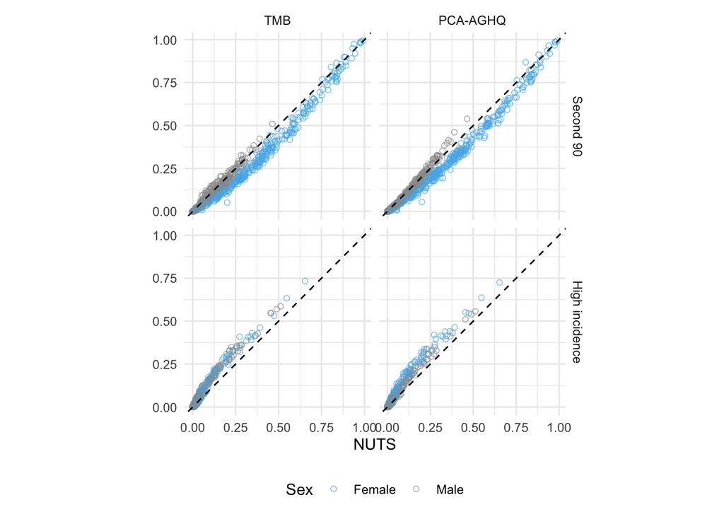

```r
df_wide <- bind_rows(
  df_wide_second90 %>%
    mutate(type = "Second 90"),
  df_wide_1inc %>%
    mutate(type = "High incidence")
)

write_csv(df_wide, "exceedance.csv")

fct_reorg <- function(fac, ...) {
  fct_recode(fct_relevel(fac, ...), ...)
}

exceedance_manuscript_plot <- df_wide %>%
  pivot_longer(cols = c("TMB", "aghq"), names_to = "method", values_to = "estimate") %>%
  mutate(
    method = fct_reorg(method, "TMB" = "TMB", "PCA-AGHQ" = "aghq"),
    type = fct_relevel(type, "Second 90", "High incidence")
  ) %>%
  ggplot(aes(x = tmbstan, y = estimate, col = sex)) +
    geom_point(shape = 1, alpha = 0.6) +
    coord_fixed(ratio = 1) +
    scale_colour_manual(values = c("#56B4E9", "#999999"), labels = c("Female", "Male")) +
    geom_abline(slope = 1, intercept = 0, linetype = "dashed") +
    facet_grid(type ~ method) +
    labs(x = "NUTS", y = "", col = "Sex") +
    theme_minimal() +
    theme(
      legend.position = "bottom"
    )

exceedance_manuscript_plot
```

```r
ggsave("exceedance.png", exceedance_manuscript_plot, h = 6.5, w = 6.25, bg = "white")
```

# 6 Excursion and contour uncertainty regions

Based on Bolin and Lindgren (2015).

- $D_m = \{s: P(x(s) > u) \geq 1 - \alpha\}$ runs into the problem of multiple hypothesis testing
- Care about $P(x(s) > u, s \in D_m)$ which is smaller than $1 - \alpha$
- You can use the marginals and adjust the threshold to control type 1 error, false discovery rate, or posteior probabilites
- Bolin and Lindgren use sequential importance sampling to estimate the joint probabilities
- $x(s) > u$ is called a positive excursion set, and $x(s) < u$ is called a negative excursion set
- The `excursions` package can calculate excursion sets, contour credible regions and level avoiding sets, excursion functions, contour maps and their quality measures, and simultaneous confidence bands

Bolin, David, and Finn Lindgren. 2015. “Excursion and Contour Uncertainty Regions for Latent Gaussian Models.” *Journal of the Royal Statistical Society: Series B: Statistical Methodology*, 85–106.